# ETC5521 Assignment 1

Education System in the US

Junhao Wang

Priya Ravindra Dingorkar

2020-08-28

This assignment is for ETC5521 Assignment 1 by Team Magpie comprising of Junhao Wang and Priya Ravindra Dingorkar.

# 1 Acknowledgements

Our sincere gratitude goes out for their guidance and encouragement to Professor Dianne Cook, Dr Emi Tanka, and the tutors Sayani Gupta and Sherry Zhang. Their culminating efforts have placed us in a position where we can generate this report collaboratively.

# 2 Introduction and Motivation

# 3 Research Question

## 3.1 Primary Question

How valuable is the investment in education among America universities?

Since tuition fee is relatively high for most students, or their families, value for money is of great concern. This question is to decover how highly valued are the tuition fees among universities in America, by analyzing the various aspects of the education system in US.

## 3.2 Secondary Questions

- How does the tuition fee vary across the different types of institutions? This information can be drawn from tuition cost, and can give a point of view of the American education system.
- What is the ratio of net-cost to total cost among America universities? This can show how much burden a student has taken.
- How is student’s career development among America universities? This information can be drawn from salary_potential, if middle-career pay differ a lot from early-career pay, then we believe there is a well career development in that university.

# 4 Data description

It is through data collection that a business or management has the quality information that they need for further analysis, study, and research to make informed decisions.

We will perform exploratory, data review in this study on the subject of **College Tuition, Diversity, and Pay Dataset**.

This collection of data primarily receives all the information from various sources but originally from the US Department of Education.

The data, taken from the original pages, turned out to be very large in size, which is why the author, for the convenience of the audience and to produce informative results, filtered the data into five comma-separated documents using web scraping in R with the support of the rvest package.

Let’s look at the small snippets of the various data sets, and get a better understanding of the variables

## 4.1 Data on Diversity

The diversity_school data set comes [The Chronicle of Higher Education](https://www.chronicle.com/article/student-diversity-at-4-725-institutions).

| name | total_enrollment | state | category | enrollment |
| --- | --- | --- | --- | --- |
| University of Phoenix-Arizona | 195059 | Arizona | Women | 134722 |
| University of Phoenix-Arizona | 195059 | Arizona | American Indian / Alaska Native | 876 |
| University of Phoenix-Arizona | 195059 | Arizona | Asian | 1959 |

- Name has data type character properties that describe the school name
- Total Enrollment has double datatype properties representing the total number of students enrolled
- State with character datatype representing the various states
- Category with character properties defining the group Group / Racial / Gender
- Enrollment with double datatype properties specifying the specific enrollment.

## 4.2 Data on History

The historical_tuition dataset been obtained from [U.S. Department of Education, National Center for Education Statistics](https://nces.ed.gov/fastfacts/display.asp?id=76)

| type | year | tuition_type | tuition_cost |
| --- | --- | --- | --- |
| All Institutions | 1985-86 | All Constant | 10893 |
| All Institutions | 1985-86 | 4 Year Constant | 12274 |
| All Institutions | 1985-86 | 2 Year Constant | 7508 |

- type variable having character datatype describes the Type of school (All, Public, Private)
- year having character format describes the corresponding Academic year
- tuition_type having character datatype refers to duration of the degree, Tuition Type All Constant (dollar inflation adjusted), 4 year degree constant, 2 year constant, Current to year, 4 year current, 2 year current
- tuition_cost having double datatype represents the education fees/Tuition cost in USD

## 4.3 Data on Salary Potential

Salary_potential data set origins from [Payscales](https://www.payscale.com/college-salary-report/best-schools-by-state/bachelors/new-hampshire).

| rank | name | state_name | early_career_pay | mid_career_pay | make_world_better_percent | stem_percent |
| --- | --- | --- | --- | --- | --- | --- |
| 1 | Auburn University | Alabama | 54400 | 104500 | 51 | 31 |
| 2 | University of Alabama in Huntsville | Alabama | 57500 | 103900 | 59 | 45 |
| 3 | The University of Alabama | Alabama | 52300 | 97400 | 50 | 15 |

- rank having double datatype properties defines the potential salary rank within state
- early_career_pay having double datatype defines the estimated early career pay in USD
- mid_career_pay having double datatype defines the estimated mid career pay in USD
- make_world_better_percent having double datatype represents the percent of alumni who think they are making the world a better place -stem_percent having double datatype defines the percent of student body in science, technology, engineering and mathematics (STEM)

## 4.4 Data on the Tuition Cost

The Tuition cost data set is obtained from [the Chronicle of Higher Education.](https://www.chronicle.com/article/tuition-and-fees-1998-99-through-2018-19)

| name | state | state_code | type | degree_length | room_and_board | in_state_tuition | in_state_total | out_of_state_tuition | out_of_state_total |
| --- | --- | --- | --- | --- | --- | --- | --- | --- | --- |
| Aaniiih Nakoda College | Montana | MT | Public | 2 Year | NA | 2380 | 2380 | 2380 | 2380 |
| Abilene Christian University | Texas | TX | Private | 4 Year | 10350 | 34850 | 45200 | 34850 | 45200 |
| Abraham Baldwin Agricultural College | Georgia | GA | Public | 2 Year | 8474 | 4128 | 12602 | 12550 | 21024 |

- in_state_tuition having double datatype depicts the Tuition fee for in-state residents in USD
- out_of_state_tuition double Tuition for out-of-state residents in USD

## 4.5 Data on Tuition Income

The tuition income has been obtained from the dataset [Tution Tracker](https://www.tuitiontracker.org/) and [Priceconomics](https://priceonomics.com/ranking-the-most-and-least-diverse-colleges-in/)

| name | state | total_price | year | campus | net_cost | income_lvl |
| --- | --- | --- | --- | --- | --- | --- |
| Piedmont International University | NC | 20174 | 2016 | On Campus | 11475 | 0 to 30,000 |
| Piedmont International University | NC | 20174 | 2016 | On Campus | 11451 | 30,001 to 48,000 |
| Piedmont International University | NC | 20174 | 2016 | On Campus | 16229 | 48_001 to 75,000 |

- campus having character datatype depicts whether the school is On or off-campus
- net_cost having double datatype denotes Net-cost - average actually paid after scholarship/award
- income_lvl having character datatype gives u information about the Income bracket

## 4.6 Data Structure and Cleaning Process

All the information gathered in these different data files was achieved by web scraping using the rvest library, html nodes, html url, and generating data set in tibble, mutating new columns and linking rows together later on. All the data was scraped and written in csv and later, the csv was read in to R environment using the readr function.

# 5 Analysis and Findings

One of the key reasons students chose to study in the USA is the prestige of the country for renowned higher education programs. Completing a degree from one of the best higher education programs in the world would make you stand out from peers of similar backgrounds and job experiences.

Let us examine and know the important facts about the US education system. We look at the various aspects when studying, the diversity of education, the history of education, the cost of tuition, income among people people in the United States, the different wages currently on the market, and similar exciting analyses.

## 5.1 The Distribution of Tution Fees in US.

Let us look at the distribution of the spectrum of tuition fees in the United States for residents and non-residents of the United States across the various types of institutions in the United States

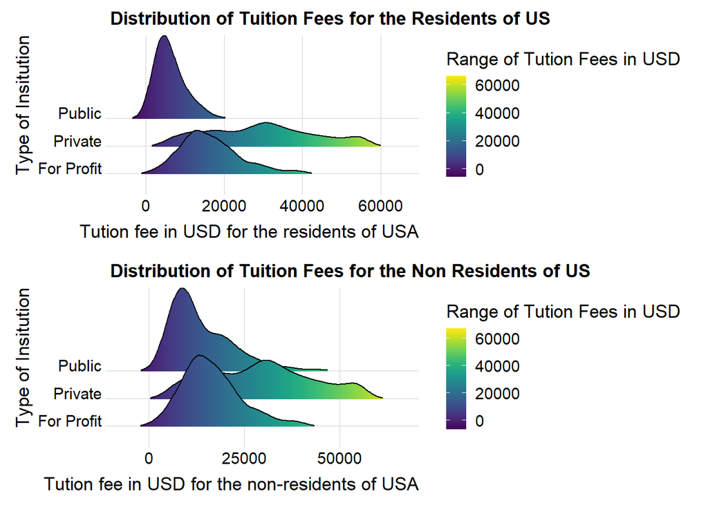

Figure 5.1: Distribution of Tution Fees in US

## 5.2 Difference in fees after any Scholarship / Awards Earned

As we know, students are providing grants for their education in various colleges, which lowers the pressure of the tuition fess by several inches. Let us understand if the amount of income is at the criterion when deciding on the student grants.

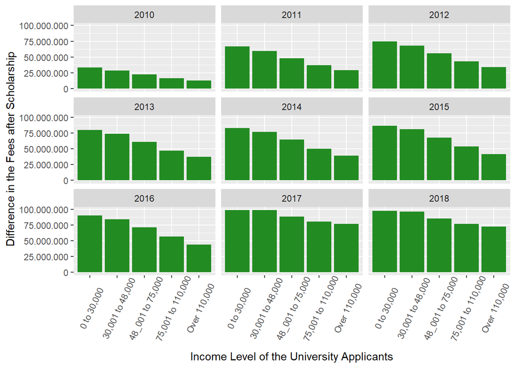

Figure 5.2: Difference in tution fees after Scholarships/Awards

In the figure 5.2 we see that after earning any scholarships / awards we note a decrease in tuition fees. A popular aspect that we find over the years is that the scholarship earned by the various applicants is often judged much of the time , based on the applicant’s income level and certainly a strong profile that the applicant would already have. Looking closely at the graph, we see that for applicants with income level above USD 110,000, there is a smaller gap in the scholarship relative to the other level of income. Applicants with income rates ranging from 0 to 30,000 USD, have a significant gap between the real tuition costs and the amount charged for the scholarship by the applicants. We also note that the gap in these patterns from the year 2010 has been showing and upward trend. We may therefore confidently state that applicants with lower incomes earn more scholarship grants when they are compared with applicants with higher incomes.

## 5.3 Student’s Career Development among America Universities

After graduation, a student’s improvement can be calculated in terms of his wage growth. Let’s look at the various states, where we see the greatest change in the wage growth.

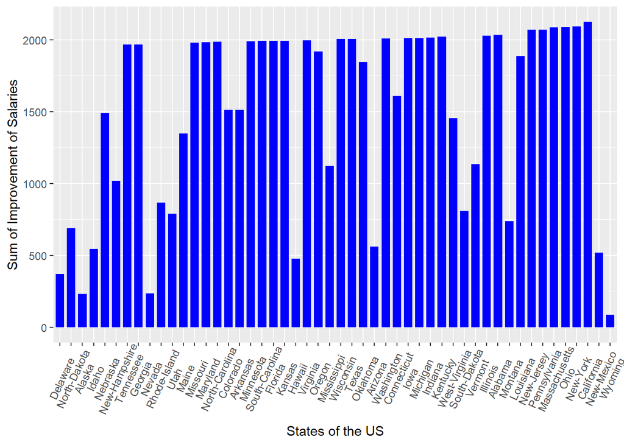

Figure 5.3: Students Career Development

In the figure 5.3 we note wage increases in various US states. We conclude that graduates, who have completed their California education, showed the greatest increase in their employment and mid-life incomes. We note, on close observation, that New Jersey, Pennsylvania, Massachusetts, Ohio and New York all show great levels of wage growth. Most of the States in the US, shows a decent growth of salaries in their existence excluding a handful. From the above graph we have reported a few states that show strong improvement levels in the salary. Furthermore, this leads us to believe that students who have completed their education in these states have increased their salaries over the years, which allows us to understand the student’s career development over the years.

After researching salary increases, our interests in terms of which universities in the United States, in which state shows an improved amount of more than 75% and their corresponding rank in that state. The table helps the user find the university’s preferred option, its ranking, in which state the university is situated.

| name | state_name | rank |
| --- | --- | --- |
| Auburn University | Alabama | 1 |
| University of Alabama in Huntsville | Alabama | 2 |
| The University of Alabama | Alabama | 3 |
| Tuskegee University | Alabama | 4 |
| Samford University | Alabama | 5 |
| Spring Hill College | Alabama | 6 |
| Birmingham Southern College | Alabama | 7 |
| University of Alabama at Birmingham | Alabama | 8 |
| University of South Alabama | Alabama | 9 |
| Alabama A&amp;M University | Alabama | 10 |

[output cut: 925 more lines]

Figure 5.4: Institutions showing more than 75% Improvement Rate in salaries after Education

## 5.4 Alumini of US that Make World a Better Place to Live

Alumni serve many important positions, such as helping create and develop the brand of an organization through word-of-mouth marketing. Alumni play an significant role in promoting organizations that benefit students and their activities. Let us look at alumni from which state a better place to stay in a world

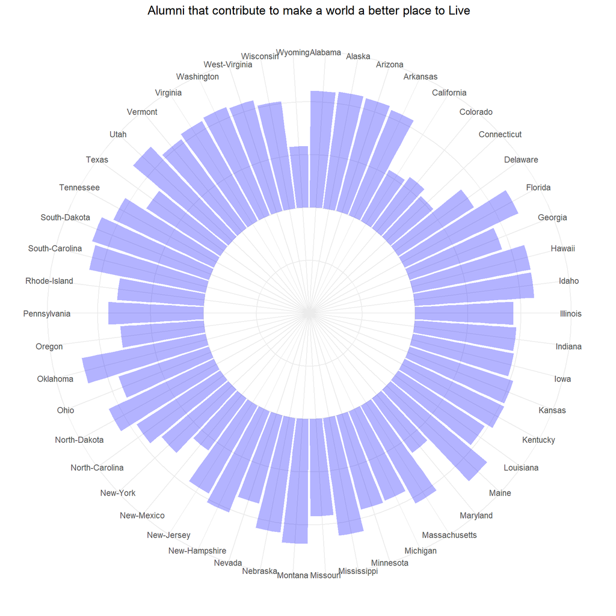

Figure 5.5: Alumini that make the world a better place to Live

# 6 References

- [Wickham et al., (2019). Welcome to the tidyverse. Journal of Open Source Software, 4(43), 1686] (https://doi.org/10.21105/joss.01686)
- Hadley Wickham, Romain François, Lionel Henry and Kirill Müller (2020). dplyr: A Grammar of Data Manipulation. R package version 1.0.1. https://CRAN.R-project.org/package=dplyr
- Hao Zhu (2019). kableExtra: Construct Complex Table with ‘kable’ and Pipe Syntax. R package version 1.1.0. https://CRAN.R-project.org/package=kableExtra
- Claus O. Wilke (2020). ggridges: Ridgeline Plots in ‘ggplot2’. R package version 0.5.2. https://CRAN.R-project.org/package=ggridges
- H. Wickham. ggplot2: Elegant Graphics for Data Analysis. Springer-Verlag New York, 2016.
- Simon Garnier (2018). viridis: Default Color Maps from ‘matplotlib’. R package version 0.5.1. https://CRAN.R-project.org/package=viridis
- Bob Rudis (2020). hrbrthemes: Additional Themes, Theme Components and Utilities for ‘ggplot2’. R package version 0.8.0. https://CRAN.R-project.org/package=hrbrthemes
- Baptiste Auguie (2017). gridExtra: Miscellaneous Functions for “Grid” Graphics. R package version 2.3. https://CRAN.R-project.org/package=gridExtra
- Hadley Wickham and Dana Seidel (2020). scales: Scale Functions for Visualization. R package version 1.1.1. https://CRAN.R-project.org/package=scales

*Yihui Xie, Joe Cheng and Xianying Tan (2020). DT: A Wrapper of the JavaScript Library ‘DataTables’. R package version 0.15. https://CRAN.R-project.org/package=DT